# DATA SCIENCE-JHU/Course 5 - Reproducible Research

Erick Yegon

2022-07-18

# Importing and Processing the dataset

## 1. Code for reading in the dataset and/or processing the data

```r
#Loading libraries
#------------------------
library("data.table")
library("ggplot2")
library(dplyr)
#------------------------

#Loading and preprocessing the data
setwd("C:/Users/Erick Yegon/Dropbox/My PC (DESKTOP-1I4SCDT)/Desktop/Althea")
fileUrl <- "https://d396qusza40orc.cloudfront.net/repdata%2Fdata%2Factivity.zip"
download.file(fileUrl, destfile = paste0(getwd(), '/repdata%2Fdata%2Factivity.zip'))
unzip("repdata%2Fdata%2Factivity.zip",exdir = "data")
data<- read.csv("./data/activity.csv")
summary(data)
```

```
##      steps            date              interval
##  Min.   :  0.00   Length:17568       Min.   :   0.0
##  1st Qu.:  0.00   Class :character   1st Qu.: 588.8
##  Median :  0.00   Mode  :character   Median :1177.5
##  Mean   : 37.38                      Mean   :1177.5
##  3rd Qu.: 12.00                      3rd Qu.:1766.2
##  Max.   :806.00                      Max.   :2355.0
##  NA's   :2304
```

```r
head(data)
```

```
##   steps       date interval
## 1    NA 2012-10-01        0
## 2    NA 2012-10-01        5
## 3    NA 2012-10-01       10
## 4    NA 2012-10-01       15
## 5    NA 2012-10-01       20
## 6    NA 2012-10-01       25
```

```r
# Removing NAs from dataAct
```

The date column was read as a factor (character data), so I’ll translate it into dates using the as.Date() function.

```r
data$date <- as.Date(data$date)
```

What is mean total number of steps taken per day? To find the mean total number of steps taken per day, first I’ll find the total number of steps for each day (ignoring missing values for now).

```r
StepsByDay <- data %>%
  group_by(date) %>%
  summarize(total.steps = sum(steps, na.rm = TRUE))
head(StepsByDay)
```

```
## # A tibble: 6 x 2
##   date       total.steps
##   <date>           <int>
## 1 2012-10-01           0
## 2 2012-10-02         126
## 3 2012-10-03       11352
## 4 2012-10-04       12116
## 5 2012-10-05       13294
## 6 2012-10-06       15420
```

Next, I’ll make a histogram of this data. The difference between a bar plot and a histogram is that a histogram shows the distribution of one quantitative variable, whereas a bar plot compares two categorical variables.

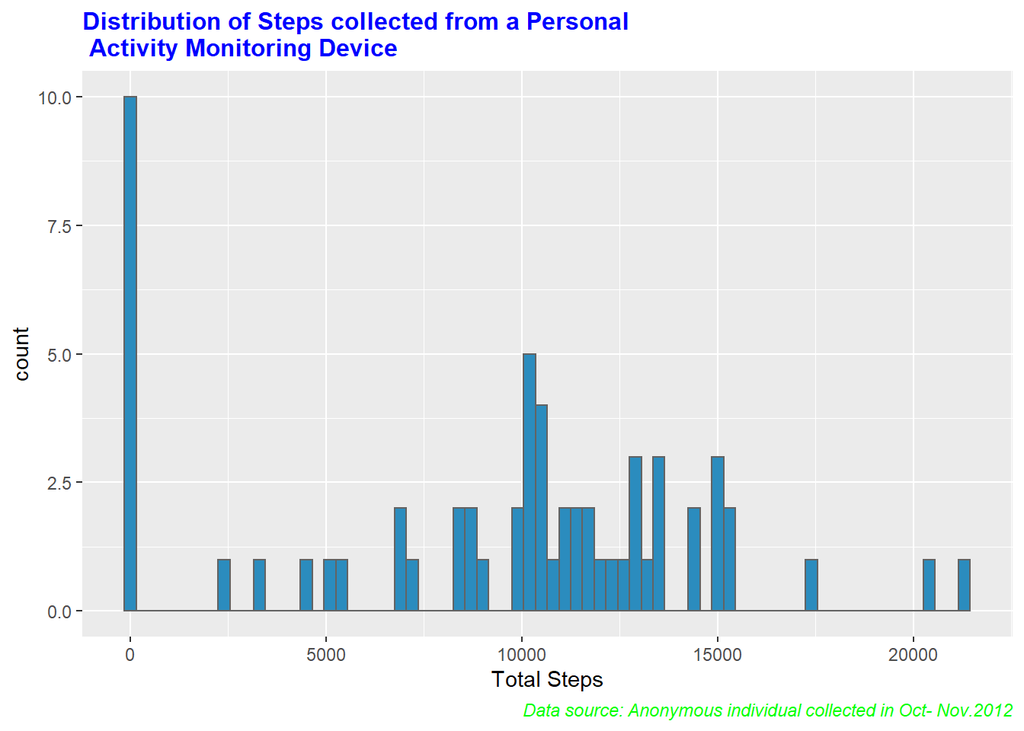

```r
StepsByDay %>%
  ggplot(aes(x = total.steps)) +
  geom_histogram(binwidth = 300, fill = "#2b8cbe", color = "#636363")+
  labs(title = "Distribution of Steps collected from a Personal \n Activity Monitoring Device",
       caption = "Data source: Anonymous individual collected in Oct- Nov.2012")+
  xlab("Total Steps")+
  theme(
  plot.title = element_text(color = "blue", size = 12, face = "bold"),
  plot.subtitle = element_text(color = "red"),
  plot.caption = element_text(color = "green", face = "italic")
)
```

For the last part of this section, Lets calculate and report the mean and median of the total number of steps taken per day using the summary function.

```r
summary(StepsByDay$total.steps)
```

```
##    Min. 1st Qu.  Median    Mean 3rd Qu.    Max.
##       0    6778   10395    9354   12811   21194
```

This person had a mean total steps per day of 9,354 and a median total steps per day of 10,395.

## What is the average daily activity pattern?

For this section, use use the original data set and compute the average number of steps taken in each 5-minute interval, averaged across all days by grouping by interval (instead of date) and we ignore missing values.

```r
averageStepsPerInterval <- data %>%
  group_by(interval) %>%
  summarize(mean.steps = mean(steps, na.rm = TRUE))
head(averageStepsPerInterval)
```

```
## # A tibble: 6 x 2
##   interval mean.steps
##      <int>      <dbl>
## 1        0     1.72
## 2        5     0.340
## 3       10     0.132
## 4       15     0.151
## 5       20     0.0755
## 6       25     2.09
```

Now that I have the averageStepsPerInterval data, I’ll make a time series plot of the average by interval.

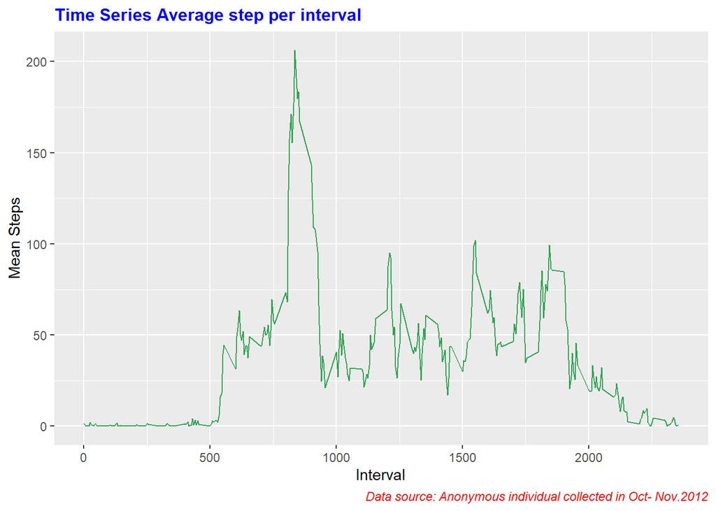

```r
averageStepsPerInterval %>%
  ggplot(aes(x = interval, y = mean.steps)) + geom_line(color = "#31a354")+
  labs(title = "Time Series Average step per interval",
       caption = "Data source: Anonymous individual collected in Oct- Nov.2012")+
  xlab("Interval")+
   ylab("Mean Steps")+
  theme(
  plot.title = element_text(color = "blue", size = 12, face = "bold"),
  plot.subtitle = element_text(color = "red"),
  plot.caption = element_text(color = "red", face = "italic")
)
```

From the plot, I can see that the maximum average number of steps occurs near the 800th interval. To find out precisely where it is, I’ll select the interval for only the row where mean.steps is the maximum.

```r
averageStepsPerInterval$interval[averageStepsPerInterval$mean.steps == max(averageStepsPerInterval$mean.steps)]
```

```
## [1] 835
```

# Imputing missing values

There are quite a few missing values in the data. First, I’ll see how many rows have NA values for each column.

```r
sapply(data, function(x) sum(is.na(x)))
```

```
##    steps     date interval
##     2304        0        0
```

We will calculate the average steps per interval above and use these values to fill in the missing data. In other words, for each interval where the number of steps is missing, we will use the mean number of steps for that interval as the value.

```r
# first join on interval so we have the mean values we need
J <- merge(data, averageStepsPerInterval, by = "interval")

# then fill in the steps column with values from the mean.steps column where steps is NA
J <- mutate(J, steps = ifelse(is.na(steps), mean.steps, steps))

# drop unnecessary columns
J <- J[c("steps", "date", "interval")]

# take a look at the result
head(J)
```

```
##      steps       date interval
## 1 1.716981 2012-10-01        0
## 2 0.000000 2012-11-23        0
## 3 0.000000 2012-10-28        0
## 4 0.000000 2012-11-06        0
## 5 0.000000 2012-11-24        0
## 6 0.000000 2012-11-15        0
```

Now we see what impact imputing the missing values had on the total number of steps taken each day. First, I’ll recompute the totalStepsByDay data.

```r
totalStepsByDay2 <- J %>%
  group_by(date) %>%
  summarize(total.steps = sum(steps))
```

We recalculate the histogram from section one.

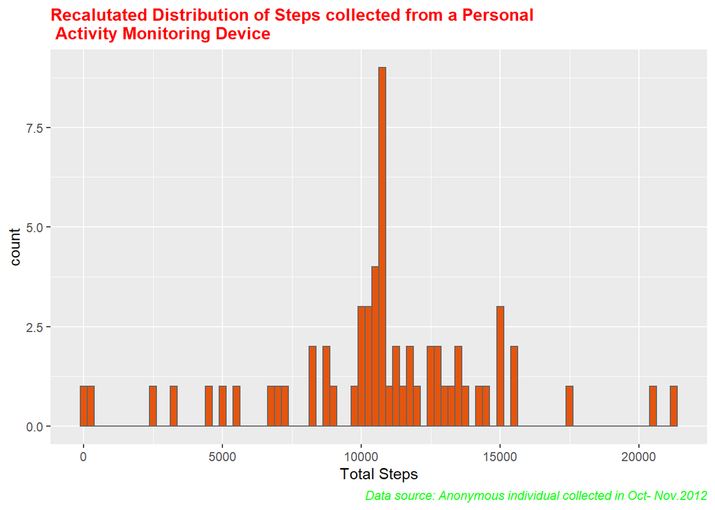

```r
totalStepsByDay2 %>% ggplot(aes(x = total.steps)) +
  geom_histogram(binwidth = 250, fill = "#e6550d", color = "#636363") +
  labs(title = "Recalutated Distribution of Steps collected from a Personal \n Activity Monitoring Device",
       caption = "Data source: Anonymous individual collected in Oct- Nov.2012")+
  xlab("Total Steps")+
  theme(
  plot.title = element_text(color = "red", size = 12, face = "bold"),
  plot.subtitle = element_text(color = "yellow"),
  plot.caption = element_text(color = "green", face = "italic")
)
```

The distribution of total steps per day has shifted noticeably. There is a much higher peak around 10,800 steps. Also, the high peak at 0 has vanished. I’ll use the summary function to see how this has changed the mean and median of the total steps.

```r
summary(totalStepsByDay2$total.steps)
```

```
##    Min. 1st Qu.  Median    Mean 3rd Qu.    Max.
##      41    9819   10766   10766   12811   21194
```

The median and mean are now the same, which makes sense given we replaced many values by the mean for those intervals. Also, both values are higher. The median is higher by a small amount, the mean is higher by an appreciable amount. Although these values differ from the version of the data with missing values, this imputed data is probably more representative of the person’s habits.

Are there differences in activity patterns between weekdays and weekends? In the final section, I’ll look at whether weekdays are different than weekends in terms of activity. First, I’ll create a new column, a factor variable called “day” indicating what day of the week it is. Then I’ll use that column to create a factor variable called “day.type” that has either the value “weekend” for a weekend day or “weekday” for a weekday.

```r
J$day <- weekdays(J$date)
J <- mutate(J, day.type = ifelse((day == "Sunday") | (day == "Saturday"), "weekend", "weekday"))
J$day.type <- factor(J$day.type)
```

Now I’ll make a multiplot of the 5-minute interval versus the average number of steps taken for both weekends and weekdays. First, I’ll calculate the average number of steps for the two categories.

```r
avgNumSteps2 <- J %>% group_by(day.type, interval) %>% summarize(avg.steps = mean(steps))
```

Then, I’ll plot the result.

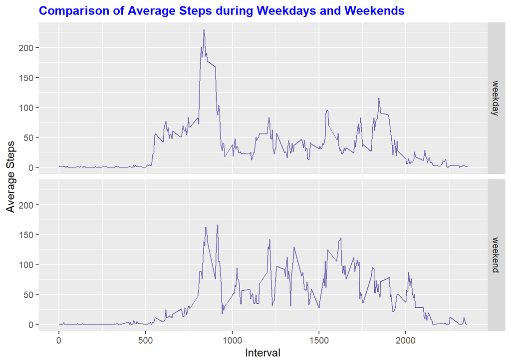

```r
ggplot(avgNumSteps2, aes(x = interval, y = avg.steps)) +
  geom_line(color = "#756bb1") +
  facet_grid(day.type ~ .)+
  labs(title = "Comparison of Average Steps during Weekdays and Weekends")+
  xlab("Interval")+
  ylab("Average Steps")+
  theme(
  plot.title = element_text(color = "blue", size = 12, face = "bold"),
  plot.subtitle = element_text(color = "red"),
  plot.caption = element_text(color = "green", face = "italic")
)
```

There do appear to be different patterns in these graphs. In both graphs, the highest peaks occur in the mornings. However, during the weekdays, the morning peak is higher. During the weekend it seems overall activity is greater throughout the day, even though the highest peak is lower.